# Analysis_TC slides

### Riccardo Petri

Matricola 167623

## Fondamenti Di Scienza Dei Dati E Laboratorio

### Modulo: **Presentazione del progetto**

### Topic: **DJ Mag Top 100 Club: Trend e Cambiamenti**

Premi in qualsiasi momento per vedere la mappa di navigazione

## 1. Radici del progetto

### Motivazioni della ricerca

- Interesse verso l'industria dell'intrattenimento notturno 🌒
- Importanza economica e culturale dei club nelle città
- *La techno berlinese diventa patrimonio immateriale dell’Unesco (2024)*

### Origine dell'interesse nel settore

- Passione per la musica elettronica e gli eventi dal vivo
- Esperienze dirette frequentando alcuni club di fama mondiale
- Passione per il campo del DJing e della produzione musicale 🎧🎵

### Focus dell'analisi 🔍

- Club in evidenza
- Evoluzione della classifica
- Distribuzione geografica
- Relazioni tra dati

## 2. Descrizione dei dati

I dati utilizzati provengono dalla classifica realizzata da  
DJ Magazine dei top 100 club (al mondo) dal 2018 al 2024 🌍

- Il dataset contiene informazioni su:
- Posizione in classifica
- Nome del club
- Città ed altre metriche rilevanti
- Alcuni dati che sarebbero stati interessanti includono:
- Specifiche demografiche dei frequentatori
- Entrate finanziarie 💰
- Genere musicale principale

### Campione parziale del dataset 📊

Attenzione! Alcune colonne sono state omesse  
per motivi di spazio e/o perchè poco utili a livello esemplificativo

|  | rank | name | city | country | lat | lng | capacity | year |
| --- | --- | --- | --- | --- | --- | --- | --- | --- |
| 0 | 1 | Green Valley | Camboriú | Brazil | -27.02736 | -48.653566 | 12000 | 2018 |
| 1 | 2 | Ushuaïa Ibiza | Playa D’en Bossa | Ibiza | 38.896173 | 1.415486 | 5000 | 2018 |
| 2 | 3 | Zouk Singapore | Singapore | Unknown | 1.357107 | 103.819499 | 2600 | 2018 |
| 3 | 4 | Echostage | Washington | D.C. | 38.895037 | -77.036543 | 3000 | 2018 |
| 4 | 5 | Hï Ibiza | Ibiza | Spain | 38.97439 | 1.419746 | 3000 | 2018 |

ecc.

L'ultima modifica al *dataset* risale al 10/06/2024

### Come sono stati ottenuti questi dati *step-by-step*

- 🔍 Analisi della struttura del sito web
- URL: djmag.com/top100clubs/{year}
- 🛠️ Realizzazione di un *web scraper*
- Raccolta e normalizzazione dei dati in un file JSON
- 📝 Normalizzazione manuale
- Aggiustamenti necessari post-raccolta

Il *dataset* e il *codice sorgente* del web scraper sono reperibili online sulla pagina GitHub @riccardopetrii

## 3. Analisi effettuata

### Indice

- 3.1 Qual'è il club in tendenza degli ultimi anni?
- Quale invece ha avuto la maggior regressione?
- 3.2 Come si è evoluta la classifica negli anni?
- Qual'è stato l'andamento delle 'New entry' e 'Re-entry'?
- 3.3 C'è una relazione tra la capacità e la posizione in classifica?
- 3.4 Cosa evidenzia la distribuzione geografica dei club dal 2018 al 2024?

## 3.1 Club in tendenza 🪩

Il club in tendenza degli ultimi anni è *'Studio 338'* con una differenza di 70 posizioni

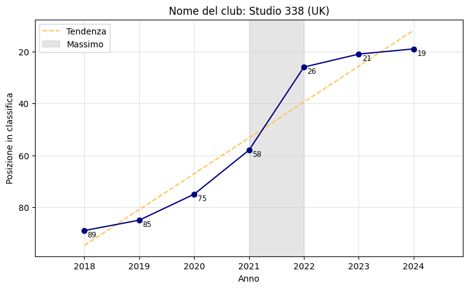

## Maggior regressione 📉

Il club con la maggior regressione degli ultimi anni è *'EGG LDN'* con una differenza di 60 posizioni

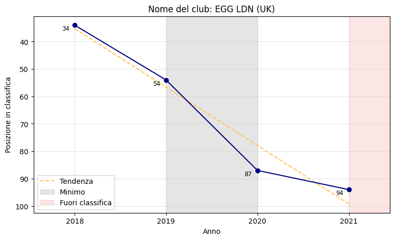

## 3.2 Analisi dei movimenti in classifica

Nel 2019 è stato registrato il maggior numero di club saliti di posizione (53);  
nel 2021 e 2023, il maggior numero di club scesi di posizione (40);  
nel 2022, il maggior numero di club che hanno mantenuto la loro posizione (5)

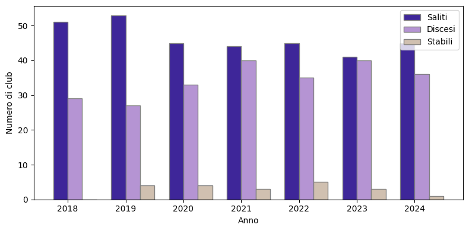

## Andamento delle *'New entry'* e *'Re-entry'*

L'anno in cui è stato registrato il maggior numero  
di 'New entry' (nuovi ingressi) è il 2020, mentre per i 'Re-entry' (rientri) è il 2018

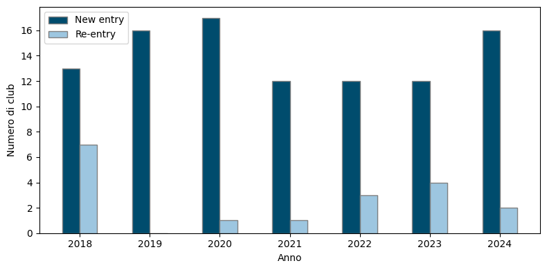

## 3.3 Relazione capacità e pos. in classifica

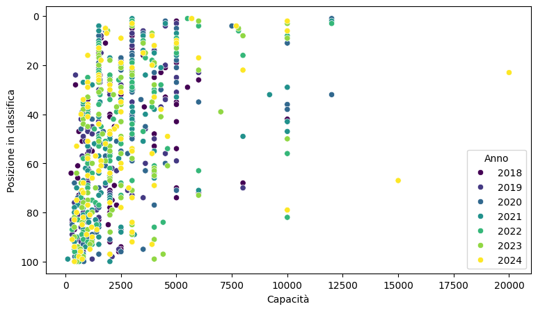

## 3.4 Distribuzione geografica dei club

La maggior concentrazione di club in classifica negli ultimi anni si trova in Europa e Regno Unito

2018

[figure not shown]

## 4. Conclusioni e valutazioni finali

Cosa abbiamo imparato e/o scoperto?

L'innovazione e la gestione attiva sono cruciali per il successo dei club;  
La distribuzione geografica e la capacità influenzano, ma non determinano, la posizione in classifica